# Assignment

#On this first assignment, applying the basic functions of the Igraph package is required. The following datasets are #going to be #used:

#* Actors dataset - undirected graph - : For the 2005 Graph Drawing conference a data set was provided of the IMDB #movie database. #We will use a reduced version of this dataset, which derived all actor-actor collaboration edges where #the actors co-starred in at #least 2 movies together between 1995 and 2004.

#You have to complete the code chunks in this document but also analyze the results, extract insights and answer the #short #questions. Fill the CSV attached with your answers, sometimes just the number is enough, some others just a #small sentence. Remember #to change the header with your email.

#In your submission please upload both the R Markdown and the CSV with the solutions.

# Loading data

#In this section, the goal is loading the datasets given, building the graph and analyzing basics metrics. Include the #edge or node attributes you consider.

#Describe the values provided by summary function on the graph object. #*1) How many nodes are there?* #*2) How many edges are there?*

```r
getwd()
```

```
[1] "C:/Users/sharu/OneDrive/Desktop/MBD/Term-2/SOCIAL NETWORKS ANALYSIS/Assignment"
```

```r
#install.packages("igraph")
library(readr)
library(ggplot2)
library(igraph)

edges <- read_tsv("imdb_actor_edges.tsv")
dim(edges)
```

```
[1] 287074      3
```

```r
head(edges)
```

| from | to | weight |
| --- | --- | --- |
| 17776 | 17778 | 6 |
| 5578 | 9770 | 3 |
| 5578 | 929 | 2 |
| 5578 | 9982 | 2 |
| 1835 | 6278 | 2 |
| 1835 | 1664 | 7 |

```r
class(edges)
```

```
[1] "spec_tbl_df" "tbl_df"      "tbl"         "data.frame"
```

```r
summary(edges)
```

```
      from             to            weight
 Min.   :    0   Min.   :    0   Min.   :  2.000
 1st Qu.: 1975   1st Qu.: 2239   1st Qu.:  2.000
 Median : 5391   Median : 5405   Median :  2.000
 Mean   : 6272   Mean   : 6333   Mean   :  3.281
 3rd Qu.: 9847   3rd Qu.: 9859   3rd Qu.:  3.000
 Max.   :17915   Max.   :17911   Max.   :118.000
```

```r
key <- read_tsv("imdb_actors_key.tsv")
dim(key)
```

```
[1] 17577     5
```

```r
head(key)
```

| id | name | movies_95_04 | main_genre | genres |
| --- | --- | --- | --- | --- |
| 15629 | Rudder, Michael (I) | 12 | Thriller | Action:1,Comedy:1,Drama:1,Fantasy:1,Horror:1,NULL:2,Romance:1,Sci-Fi:1,Thriller:2,War:1 |
| 5026 | Morgan, Debbi | 16 | Drama | Comedy:2,Documentary:1,Drama:6,Horror:2,NULL:3,Romance:2 |
| 11252 | Bellows, Gil | 33 | Drama | Comedy:6,Documentary:1,Drama:7,Family:1,Fantasy:1,Horror:1,Mystery:2,NULL:2,Romance:6,Short:2,Thriller:4 |
| 5150 | Dray, Albert | 20 | Comedy | Comedy:6,Crime:1,Documentary:1,Drama:4,NULL:5,Romance:1,Short:1,Thriller:1 |
| 4057 | Daly, Shane (I) | 18 | Drama | Comedy:2,Crime:1,Drama:7,Horror:1,Music:1,Musical:1,Romance:1,Thriller:4 |
| 12373 | Macfadyen, Angus | 24 | Drama | Action:1,Adventure:1,Documentary:1,Drama:7,Family:1,Fantasy:1,Horror:2,NULL:1,Romance:2,Sci-Fi:1,Short:2,Thriller:4 |

```r
class(key)
```

```
[1] "spec_tbl_df" "tbl_df"      "tbl"         "data.frame"
```

```r
g <- graph_from_data_frame(d = edges, directed = FALSE, vertices = key)

vcount(g)
```

```
[1] 17577
```

```r
ecount(g)
```

```
[1] 287074
```

# Degree distribution

#Analyse the degree distribution. Compute the total degree distribution. #*3) How does this distributions look like?* #*4) What is the maximum degree?* #*5) What is the minimum degree?*

```r
is.directed(g)
```

```
[1] FALSE
```

```r
summary(g)
```

```
IGRAPH 69f8eb8 UNW- 17577 287074 --
+ attr: name (v/c), movies_95_04 (v/n), main_genre (v/c), genres (v/c), weight (e/n)
```

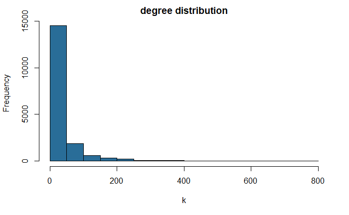

```r
deg <- degree(g)

hist(deg, main = "degree distribution", xlab = "k", col = "#296d98")
```

```r
max(deg)
```

```
[1] 784
```

```r
min(deg)
```

```
[1] 1
```

# Network Diameter and Average Path Length

#*6) What is the diameter of the graph?* #*7) What is the avg path length of the graph?*

```r
diameter(g, directed = FALSE)
```

[output not shown]

# Node importance: Centrality measures

#Obtain the distribution of the number of movies made by an actor and the number of genres in which an actor starred in. It may be #useful to analyze and discuss the results to be obtained in the following exercises.

```r
V(g)
```

```
+ 17577/17577 vertices, named, from 69f8eb8:
   [1] Rudder, Michael (I)                Morgan, Debbi                      Bellows, Gil
   [4] Dray, Albert                       Daly, Shane (I)                    Macfadyen, Angus
   [7] Djola, Badja                       Twiggy                             Winfrey, Oprah
  [10] Champagne (II)                     Sweet, Jay (I)                     Roach, Martin
  [13] Welch, Raquel                      Yue, Shawn                         Landstr<f6>m, <d6>rjan
  [16] Scarborough, Adrian                Valc<e1>rcel, Javier               Weinberg, Max (I)
  [19] Hingle, Pat                        Yamazaki, Takumi                   Sokoloff, Marla
  [22] Sims, Molly                        Benson, Amber                      Warhol, Andy
  [25] Rogers, Debra Jean                 Diego, Gabino                      Carvana, Hugo (I)
  [28] Baker, Carroll                     B<f6>hm, Katharina                 James, Robbie
+ ... omitted several vertices
```

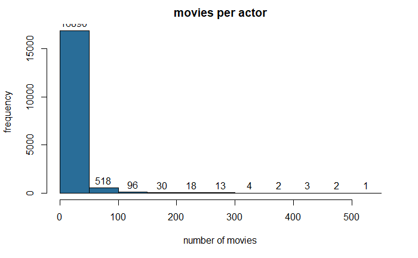

```r
hist(V(g)$movies_95_04,
    main = "movies per actor",
    xlab = "number of movies",
    ylab = "frequency",
    labels = TRUE,
    col = "#296d98")
```

#Obtain three vectors with the degree, betweenness and closeness for each vertex of the actors’ graph.

```r
deg <- degree(g)
btw <- betweenness(g, v = V(g), normalized = TRUE)
cl  <- closeness(g, v = V(g), normalized = TRUE)
```

```
At centrality.c:2617 :closeness centrality is not well-defined for disconnected graphs
```

#Obtain the list of the 20 actors with the largest degree centrality. It can be useful to show a list with the degree, the name of #the actor, the number of movies, the main genre, and the number of genres in which the actor has participated.

#*8) Who is the actor with highest degree centrality?* #*9) How do you explain the high degree of the top-20 list??*

```r
library(sqldf)
deg_cent<- sort(deg,decreasing=TRUE)[1:20]

deg_df <- as.data.frame(deg_cent)
deg_df <- cbind(Name=rownames(deg_df),deg_df)

# Join degree df with df_key variables id, movies, genre
deg_df2 <- sqldf("select a.*, b.id, b.movies_95_04, b.main_genre, b.genres from deg_df a left outer join key b on a.Name=b.name")

deg_df2
```

| Name | deg_cent | id | movies_95_04 | main_genre | genres |
| --- | --- | --- | --- | --- | --- |
| Davis, Mark (V) | 784 | 162 | 540 | Adult | Action:1,Adult:429,Comedy:3,Crime:1,Documentary:5,Drama:6,Fantasy:1,NULL:92,Sci-Fi:1,Short:1 |
| Sanders, Alex (I) | 610 | 1743 | 467 | Adult | Action:1,Adult:380,Adventure:1,Comedy:2,Documentary:7,Drama:3,NULL:65,Sci-Fi:3,Short:2,Thriller:3 |
| North, Peter (I) | 599 | 1754 | 460 | Adult | Action:1,Adult:389,Documentary:5,Drama:5,NULL:55,Sci-Fi:3,Short:1,Thriller:1 |
| Marcus, Mr. | 584 | 1802 | 435 | Adult | Adult:343,Crime:1,Documentary:2,NULL:86,Short:1,Thriller:2 |
| Tedeschi, Tony | 561 | 407 | 364 | Adult | Adult:286,Adventure:1,Comedy:1,Documentary:2,Drama:5,Fantasy:1,NULL:63,Romance:2,Sci-Fi:1,Short:1,Thriller:1 |
| Dough, Jon | 555 | 164 | 300 | Adult | Adult:248,Adventure:1,Comedy:1,Documentary:1,Drama:5,NULL:34,Sci-Fi:8,Short:2 |
| Stone, Lee (II) | 545 | 179 | 403 | Adult | Adult:310,Comedy:1,Documentary:1,Fantasy:2,NULL:87,Romance:1,Thriller:1 |
| Voyeur, Vince | 533 | 176 | 370 | Adult | Action:1,Adult:303,Comedy:3,Crime:1,Documentary:3,Drama:1,NULL:50,Sci-Fi:3,Short:3,Thriller:2 |
| Lawrence, Joel (II) | 500 | 175 | 315 | Adult | Adult:257,Comedy:1,Documentary:1,Musical:1,NULL:53,Sci-Fi:1,Short:1 |
| Steele, Lexington | 493 | 160 | 429 | Adult | Adult:340,Comedy:1,Documentary:4,Drama:1,Fantasy:1,Horror:1,NULL:80,Thriller:1 |

[output cut: 10 more lines]

```r
NA
```

#Obtain the list of the 20 actors with the largest betweenness centrality. Show a list with the betweenness, the name of the actor, #the number of movies, the main genre, and the number of genres in which the actor has participated.

#*10) Who is the actor with highest betweennes?* #*11) How do you explain the high betweenness of the top-20 list?*

```r
btw_cent <- sort(btw,decreasing=TRUE)[1:20]

btw_df <- as.data.frame(btw_cent)
btw_df <- cbind(Name=rownames(btw_df),btw_df)

# Join degree df with df_key variables id, movies, genre
btw_df2 <- sqldf("select a.*, b.id, b.movies_95_04, b.main_genre, b.genres from btw_df a left outer join key b on a.Name=b.name")

btw_df2
```

| Name | btw_cent | id | movies_95_04 | main_genre | genres |
| --- | --- | --- | --- | --- | --- |
| Jeremy, Ron | 0.05460652 | 2108 | 280 | Adult | Adult:149,Adventure:1,Animation:1,Comedy:15,Documentary:26,Drama:15,Horror:9,Music:2,Musical:1,NULL:43,Romance:3,Sci-Fi:8,Short:4,Thriller:3 |
| Shahlavi, Darren | 0.02785818 | 14458 | 16 | Action | Action:4,Comedy:3,Documentary:1,Drama:1,Fantasy:1,Horror:1,Sci-Fi:1,Short:1,Thriller:3 |
| Del Rosario, Monsour | 0.02762785 | 17308 | 20 | Action | Action:8,Drama:3,Fantasy:1,Horror:2,NULL:1,Romance:1,Sci-Fi:1,Thriller:2,War:1 |
| Chan, Jackie (I) | 0.02685814 | 3284 | 59 | Comedy | Action:2,Comedy:13,Crime:4,Documentary:18,Family:3,Fantasy:1,Horror:1,Music:1,NULL:4,Romance:2,Short:7,Thriller:3 |
| Cruz, Penlope | 0.02415482 | 564 | 46 | Drama | Adventure:1,Comedy:2,Documentary:5,Drama:6,Family:5,Music:3,Mystery:2,NULL:3,Romance:6,Short:5,Thriller:2,War:3,Western:3 |
| Depardieu, Grard | 0.02135161 | 285 | 56 | Comedy | Adventure:1,Comedy:15,Crime:2,Documentary:11,Drama:12,Family:2,Fantasy:1,NULL:2,Romance:7,Thriller:1,War:2 |
| Arquette, David | 0.01759523 | 551 | 45 | Comedy | Action:3,Adult:1,Adventure:2,Animation:1,Comedy:8,Crime:2,Documentary:6,Drama:5,Family:2,Music:1,NULL:3,Romance:3,Sci-Fi:1,Short:2,Thriller:4,Western:1 |
| Bachchan, Amitabh | 0.01626876 | 13723 | 35 | Romance | Action:1,Comedy:1,Crime:1,Documentary:1,Drama:8,Family:1,Fantasy:1,Musical:2,Mystery:1,NULL:5,Romance:11,Sci-Fi:1,War:1 |
| Soualem, Zinedine | 0.01533058 | 5083 | 65 | Comedy | Animation:1,Comedy:17,Crime:3,Documentary:1,Drama:8,Family:1,Fantasy:1,NULL:13,Romance:3,Sci-Fi:1,Short:15,Thriller:1 |
| Kier, Udo | 0.01509675 | 5295 | 69 | Drama | Action:2,Animation:2,Comedy:10,Crime:2,Documentary:5,Drama:13,Fantasy:6,Horror:3,Music:1,NULL:6,Romance:3,Sci-Fi:1,Short:5,Thriller:9,War:1 |

[output cut: 10 more lines]

```r
NA
```

#Obtain the list of the 20 actors with the largest closeness centrality. Show a list with the closeness the name of the actor, the #number of movies, the main genre, and the number of genres in which the actor has participated.

#*12) Who is the actor with highest closeness centrality?* #*13) How do you explain the high closeness of the top-20 list?*

```r
cl_cent <- sort(cl,decreasing=TRUE)[1:20]

cl_df <- as.data.frame(cl_cent)
cl_df <- cbind(Name=rownames(cl_df),cl_df)

# Join degree df with df_key variables id, movies, genre
cl_df2 <- sqldf("select a.*, b.id, b.movies_95_04, b.main_genre, b.genres from cl_df a left outer join key b on a.Name=b.name")

cl_df2
```

| Name | cl_cent | id | movies_95_04 | main_genre | genres |
| --- | --- | --- | --- | --- | --- |
| Diaz, Cameron | 0.007752434 | 503 | 59 | Drama | Adult:1,Animation:1,Comedy:4,Crime:1,Documentary:14,Drama:7,Family:3,Music:4,Mystery:2,NULL:5,Romance:5,Short:9,Thriller:3 |
| Goldberg, Whoopi | 0.007751894 | 3213 | 109 | Comedy | Adventure:3,Animation:1,Comedy:16,Documentary:35,Drama:11,Family:12,Fantasy:2,Music:9,Musical:1,Mystery:1,NULL:11,Romance:1,Sci-Fi:2,Short:4 |
| Hanks, Tom | 0.007750574 | 701 | 75 | Family | Animation:3,Comedy:5,Documentary:32,Drama:6,Family:6,Fantasy:1,Music:5,Mystery:1,NULL:2,Romance:2,Short:9,Thriller:2,War:1 |
| Berry, Halle | 0.007750348 | 3268 | 63 | Family | Adventure:1,Comedy:2,Crime:1,Documentary:23,Drama:5,Family:8,Fantasy:3,Music:5,Mystery:1,NULL:6,Romance:2,Sci-Fi:1,Short:3,Thriller:2 |
| Jackson, Samuel L. | 0.007749323 | 1529 | 97 | Drama | Action:3,Adventure:1,Comedy:3,Crime:3,Documentary:34,Drama:13,Family:8,Fantasy:1,Music:5,Mystery:1,NULL:6,Sci-Fi:3,Short:7,Thriller:9 |
| Douglas, Michael (I) | 0.007748199 | 3308 | 41 | Family | Comedy:1,Crime:1,Documentary:15,Drama:2,Family:4,Music:4,Mystery:1,NULL:3,Romance:1,Short:7,Thriller:2 |
| De Niro, Robert | 0.007746768 | 756 | 51 | Comedy | Animation:1,Comedy:7,Crime:1,Documentary:13,Drama:7,Family:3,Horror:1,Music:4,NULL:3,Sci-Fi:1,Short:5,Thriller:4,War:1 |
| Willis, Bruce (I) | 0.007746191 | 3169 | 52 | Thriller | Adventure:1,Comedy:2,Crime:4,Documentary:13,Drama:3,Fantasy:1,Music:2,Mystery:2,NULL:3,Romance:2,Sci-Fi:4,Short:6,Thriller:8,War:1 |
| Hopper, Dennis | 0.007745799 | 2896 | 106 | Music | Action:3,Adult:1,Adventure:1,Comedy:3,Crime:1,Documentary:38,Drama:11,Family:3,Horror:1,Music:12,Mystery:1,NULL:7,Romance:1,Sci-Fi:3,Short:9,Thriller:11 |
| Washington, Denzel | 0.007745563 | 3260 | 49 | Family | Comedy:1,Crime:2,Documentary:18,Drama:5,Family:7,Music:1,Mystery:1,NULL:4,Short:6,Thriller:4 |

[output cut: 10 more lines]

```r
NA
```

#Network Models (Optional) #Explore the Erdös-Renyi model and compare its structural properties to those of real-world networks (actors):

```r
g_er <- erdos.renyi.game(17577,287074, type = "gnm")

plot(g_er, vertex.label= key, edge.arrow.size=0.02,vertex.size = 0.5, xlab = "Random Network: G(N,L) model")
```

[output not shown]

- Degree distribution P(k)
- Network Diameter and Average Path Length
- (Global and Local) Clustering Coefficient

#Comunity detection (Optional) #Use any community detection algorithm for the actors’ network and discuss whether the communities found make sense #according to the #vertex labels.